# Amgen_data

Kalyan Srivastava

4/5/2021

#Importing the data

|  | Subjects | Collection_Time | Count | Immune_Marker | Therapy_Given |
| --- | --- | --- | --- | --- | --- |
| 1 | a | day1 | 388.7 | CD4 | TreatType1 |
| 2 | a | day1 | 476.1 | CD8 | TreatType1 |
| 3 | a | day1 | 23 | TLR2 | TreatType1 |
| 4 | b | day1 | 1462.8 | CD4 | TreatType1 |
| 5 | b | day1 | 1888.3 | CD8 | TreatType1 |
| 6 | b | day1 | 43.7 | TLR2 | TreatType1 |
| 7 | f | day1 | 584.2 | CD4 | TreatType1 |
| 8 | f | day1 | 2789.9 | CD8 | TreatType1 |
| 9 | f | day1 | 13.8 | TLR2 | TreatType1 |
| 10 | l | day1 | 207 | CD4 | TreatType1 |

[output cut: 244 more lines]

```
##    Subjects         Collection_Time        Count         Immune_Marker
##  Length:254         Length:254         Min.   :    9.2   Length:254
##  Class :character   Class :character   1st Qu.:  231.2   Class :character
##  Mode  :character   Mode  :character   Median :  671.6   Mode  :character
##                                        Mean   : 1309.5
##                                        3rd Qu.: 1316.8
##                                        Max.   :15435.3
##  Therapy_Given
##  Length:254
##  Class :character
##  Mode  :character
##
##
##
```

```
## The times point of observations are :     day1 day15 day22 day29 day8
```

### Please provide a version of this graph with each subject’s digital_count connected by a line, and a unique shape and color for each subject

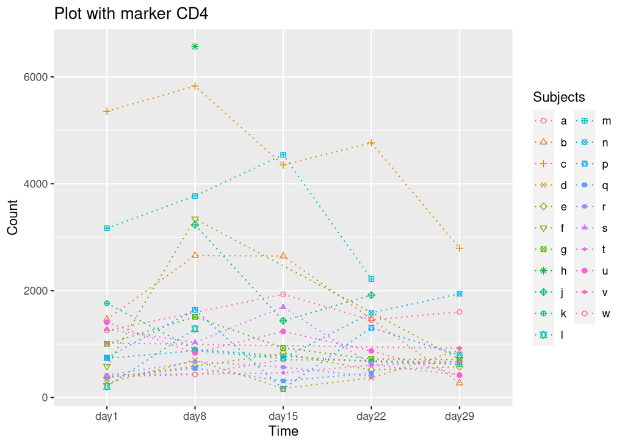

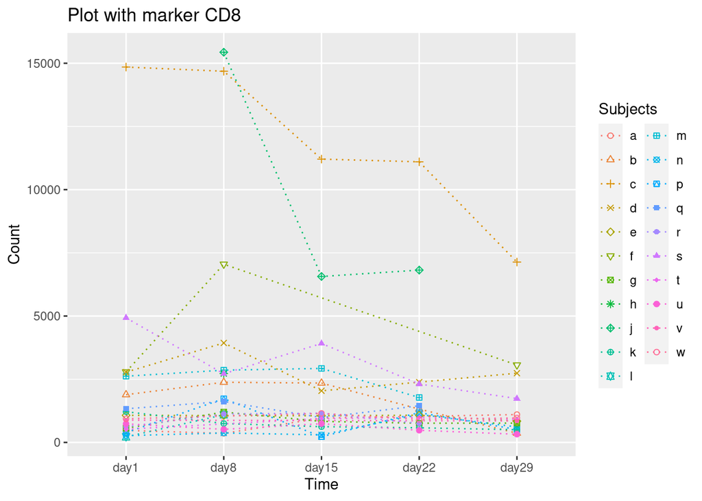

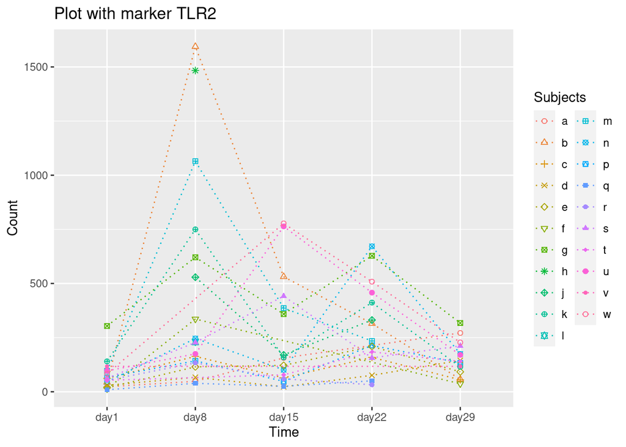

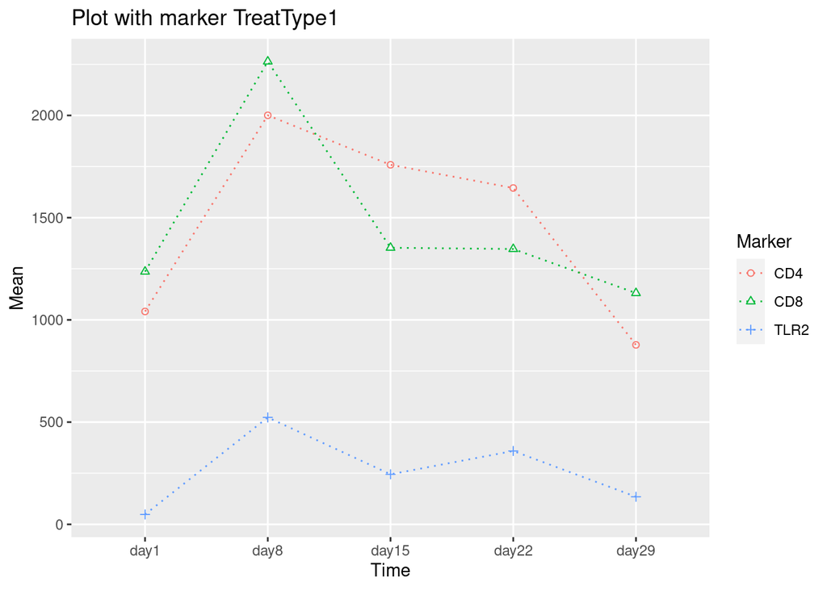

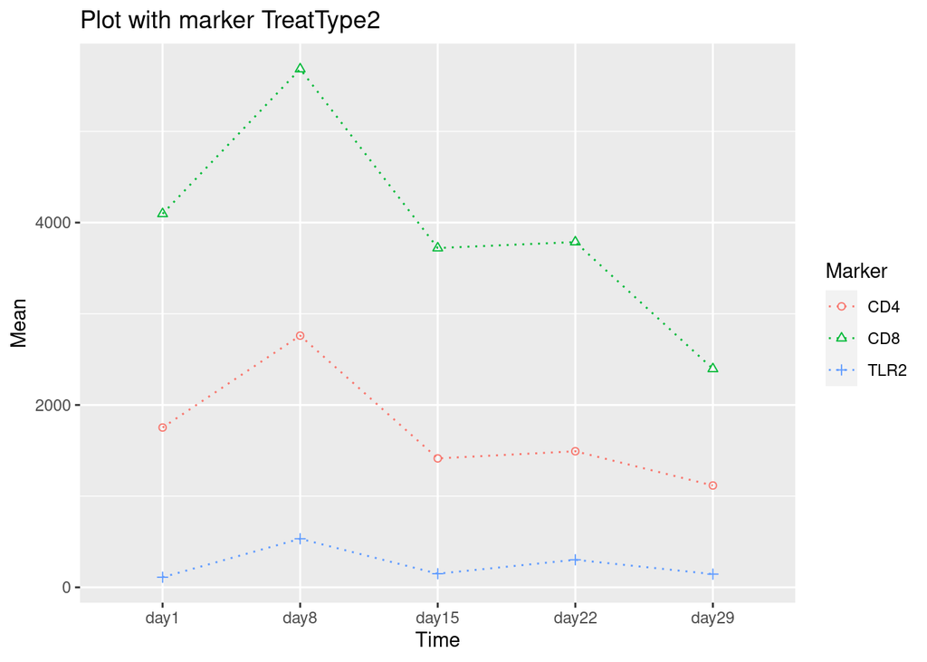

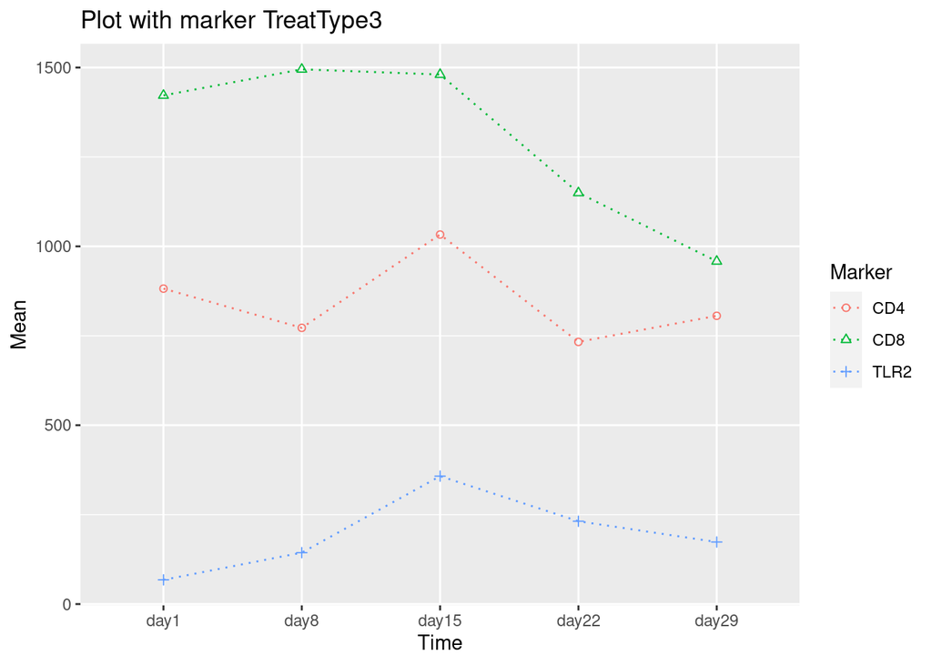

### Please convert the input data table to another table in which each sample_time become a separate column filled with corresponding digital counts and other columns remain

|  | Subjects | Immune_Marker | Therapy_Given | day1 | day8 | day15 | day22 | day29 |
| --- | --- | --- | --- | --- | --- | --- | --- | --- |
| 1 | a | CD4 | TreatType1 | 388.7 | 430.1 | 708.4 |  | 667 |
| 2 | a | CD8 | TreatType1 | 476.1 | 358.8 | 961.4 |  | 1101.7 |
| 3 | a | TLR2 | TreatType1 | 23 | 48.3 | 156.4 |  | 271.4 |
| 4 | b | CD4 | TreatType1 | 1462.8 | 2656.5 | 2647.3 | 1472 | 271.4 |
| 5 | b | CD8 | TreatType1 | 1888.3 | 2380.5 | 2348.3 | 1320.2 | 365.7 |
| 6 | b | TLR2 | TreatType1 | 43.7 | 1593.9 | 531.3 | 315.1 | 57.5 |
| 7 | c | CD4 | TreatType2 | 5354.4 | 5828.2 | 4351.6 | 4765.6 | 2792.2 |
| 8 | c | CD8 | TreatType2 | 14848.8 | 14683.2 | 11207.9 | 11099.8 | 7134.6 |
| 9 | c | TLR2 | TreatType2 | 62.1 | 163.3 | 64.4 | 158.7 | 55.2 |
| 10 | d | CD4 | TreatType2 | 269.1 | 699.2 | 170.2 | 368 | 885.5 |

[output cut: 53 more lines]

### Please test for each marker whether Day 8 and Day 1 differs at alpha = 0.05 under each treatment

```
## The p value for marker CD4 is:    0.1113102
```

```
## The p value for marker CD8 is:    0.3055361
```

```
## The p value for marker TLR2 is:   0.004952685
```

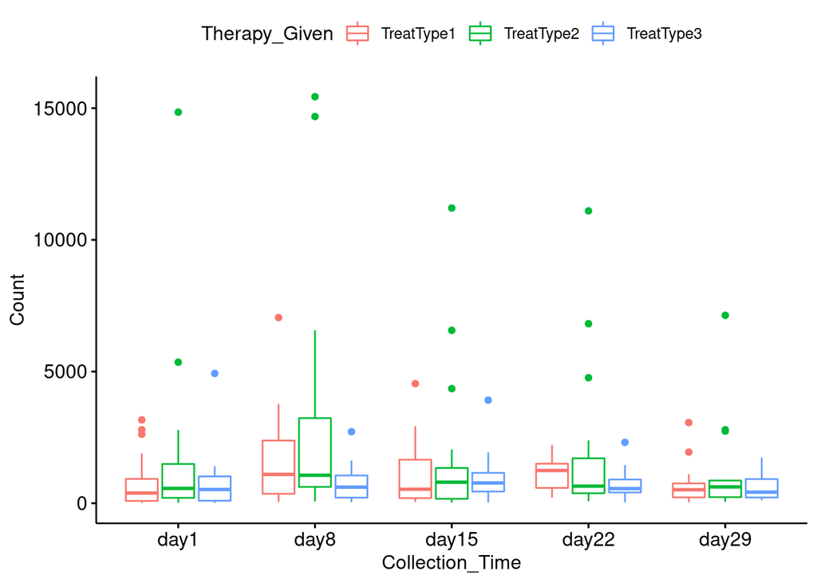

```
##                 Df    Sum Sq  Mean Sq F value Pr(>F)
## Therapy_Given    2  52478535 26239268   4.231 0.0173 *
## Collection_Time  1   9595917  9595917   1.547 0.2165
## Residuals       98 607816955  6202214
## ---
## Signif. codes:  0 '***' 0.001 '**' 0.01 '*' 0.05 '.' 0.1 ' ' 1
```

### If you had to analyze 1 million markers, how would you parallelize the tests from question 4 on a multi-processor machine? Please demonstrate this parallelization method using just the markers available in the spreadsheet

```
## [1] "without parallelizing"
```

```
##
##  Welch Two Sample t-test
##
## data:  xA and xB
## t = -1.6416, df = 29.465, p-value = 0.1113
## alternative hypothesis: true difference in means is not equal to 0
## 95 percent confidence interval:
##  -1915.8586   209.1107
## sample estimates:
## mean of x mean of y
##  1169.732  2023.106
##
##
##  Welch Two Sample t-test
##
## data:  xA and xB
## t = -1.0418, df = 31.106, p-value = 0.3055
## alternative hypothesis: true difference in means is not equal to 0
## 95 percent confidence interval:
##  -4039.472  1307.718
## sample estimates:
## mean of x mean of y
##  2057.289  3423.167
##
##
##  Welch Two Sample t-test
##
## data:  xA and xB
## t = -3.2091, df = 17.671, p-value = 0.004953
## alternative hypothesis: true difference in means is not equal to 0
## 95 percent confidence interval:
##  -611.3600 -127.1956
## sample estimates:
## mean of x mean of y
##  73.21667 442.49444
```

```
## [1] "with parallelizing"
```

```
##
##  Welch Two Sample t-test
##
## data:  xA and xB
## t = -1.6416, df = 29.465, p-value = 0.1113
## alternative hypothesis: true difference in means is not equal to 0
## 95 percent confidence interval:
##  -1915.8586   209.1107
## sample estimates:
## mean of x mean of y
##  1169.732  2023.106
##
##
##  Welch Two Sample t-test
##
## data:  xA and xB
## t = -1.0418, df = 31.106, p-value = 0.3055
## alternative hypothesis: true difference in means is not equal to 0
## 95 percent confidence interval:
##  -4039.472  1307.718
## sample estimates:
## mean of x mean of y
##  2057.289  3423.167
##
##
##  Welch Two Sample t-test
##
## data:  xA and xB
## t = -3.2091, df = 17.671, p-value = 0.004953
## alternative hypothesis: true difference in means is not equal to 0
## 95 percent confidence interval:
##  -611.3600 -127.1956
## sample estimates:
## mean of x mean of y
##  73.21667 442.49444
```

### Please automate the table view for different layouts, i.e., write a function that takes the input data and another parameter indicating a categorical (nominal) variable so that the output of this function will produce a new table in which each level of the indicated variable become a separate column filled with corresponding digital_counts and others columns remain. In the data provided for the quiz, except “digital_count”, all other variables are factors

|  | Subjects | Collection_Time | Therapy_Given | CD4 | CD8 | TLR2 |
| --- | --- | --- | --- | --- | --- | --- |
| 1 | a | day1 | TreatType1 | 388.7 | 476.1 | 23 |
| 2 | a | day8 | TreatType1 | 430.1 | 358.8 | 48.3 |
| 3 | a | day15 | TreatType1 | 708.4 | 961.4 | 156.4 |
| 4 | a | day29 | TreatType1 | 667 | 1101.7 | 271.4 |
| 5 | b | day1 | TreatType1 | 1462.8 | 1888.3 | 43.7 |
| 6 | b | day8 | TreatType1 | 2656.5 | 2380.5 | 1593.9 |
| 7 | b | day15 | TreatType1 | 2647.3 | 2348.3 | 531.3 |
| 8 | b | day22 | TreatType1 | 1472 | 1320.2 | 315.1 |
| 9 | b | day29 | TreatType1 | 271.4 | 365.7 | 57.5 |
| 10 | c | day1 | TreatType2 | 5354.4 | 14848.8 | 62.1 |

[output cut: 75 more lines]